# Practical on clustering

Jip de Kok

02 February, 2026

## Reminder of what we are going to look at

Recall that the ultimate goal of any kind of modelling process is to **derive a simpler low-dimensional representation** of a dataset.

For example, if we have a scatter of points on an *x-y plot* we are familiar to reduce all the complexity of the data into only **two** descriptors - it will be the INTERCEPT and the SLOPE of a straight line (of course we are assuming that a linear description is appropriate in the first place).

Over the top of this compressed description is what (we hope) contains only purely random NOISE. If we have done a good job as statisticians and modellers, then we might have some confidence that the compressed descriptors really do indeed capture the SIGNAL in the data.

- SIGNAL - patterns generated by the phenomenon that we are actually interested to understand;
- NOISE - random variation that we are not interested in.

### Recap two modelling approaches that may be complementary

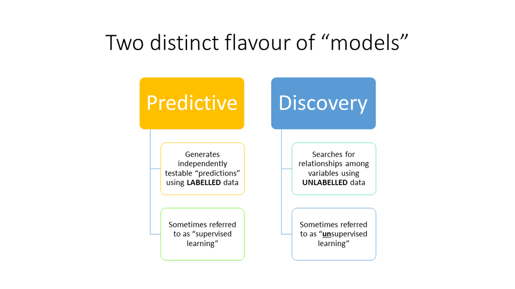

## Get the data ready

Reminder that these are steps we have already seen before.

```r
source("handy_dandy_functions.R")

list.of.packages <- c("dplyr",
                      "magrittr",
                      "ggplot2",
                      "GGally",
                      "lubridate") #a list of packages to use

installRequiredPackages(list.of.packages)
```

```
## [1] "dplyr"     "magrittr"  "ggplot2"   "GGally"    "lubridate"
```

```r
pathToData <- './open_covid_data' #this means "where my markdown script is, there is a subfolder called open-covid-data"

# Here we read the csv file into R
rawOpenCovid <- read.csv( file.path(pathToData,'Covid_cleaned.csv'))

# Now we define some of the datatypes
recodedOpenCovid <- dplyr::mutate(rawOpenCovid,
    # continent is a category, so we define it as a factor
    continent = as.factor(continent),
    # location is a category, so we define it as a factor
    location = as.factor(location),
    # date will be defined as a date type instead of just text
    date = as.Date(date)
  )

# Select only some of the variables to make it easier to read
recodedOpenCovid <- dplyr::select(recodedOpenCovid,
                                  continent,
                                  location,
                                  date,
                                  total_cases_per_million,
                                  total_deaths_per_million,
                                  population_density,
                                  median_age,
                                  aged_65_older,
                                  gdp_per_capita,
                                  extreme_poverty,
                                  cardiovasc_death_rate,
                                  hospital_beds_per_thousand,
                                  life_expectancy,
                                  human_development_index
                                  )

# Print a summary overview of the data
summary(recodedOpenCovid)
```

```
##          continent          location          date
##  Africa       :8311   Albania   :  366   Min.   :2020-10-01
##  Asia         :7554   Algeria   :  366   1st Qu.:2021-01-02
##  Europe       :9882   Argentina :  366   Median :2021-04-04
##  North America:2927   Australia :  366   Mean   :2021-04-03
##  Oceania      : 725   Austria   :  366   3rd Qu.:2021-07-04
##  South America:2551   Bangladesh:  366   Max.   :2021-10-01
##                       (Other)   :29754
##  total_cases_per_million total_deaths_per_million population_density
##  Min.   :8.277e+00       Min.   :   0.136         Min.   :   1.98
##  1st Qu.:2.322e+03       1st Qu.:  39.926         1st Qu.:  41.28
##  Median :1.462e+04       Median : 253.593         Median :  81.72
##  Mean   :2.960e+04       Mean   : 587.959         Mean   : 147.98
##  3rd Qu.:4.950e+04       3rd Qu.: 972.679         3rd Qu.: 145.72
##  Max.   :2.174e+05       Max.   :3258.812         Max.   :1454.04
##
##    median_age    aged_65_older    gdp_per_capita    extreme_poverty
##  Min.   :15.10   Min.   : 2.168   Min.   :  752.8   Min.   : 0.100
##  1st Qu.:25.40   1st Qu.: 5.098   1st Qu.: 5034.7   1st Qu.: 0.500
##  Median :32.40   Median : 8.273   Median :14103.5   Median : 1.300
##  Mean   :32.29   Mean   :10.240   Mean   :19047.4   Mean   : 9.789
##  3rd Qu.:40.80   3rd Qu.:15.504   3rd Qu.:26808.2   3rd Qu.:12.000
##  Max.   :47.90   Max.   :23.021   Max.   :94278.0   Max.   :71.400
##
##  cardiovasc_death_rate hospital_beds_per_thousand life_expectancy
##  Min.   : 86.0         Min.   : 0.300             Min.   :60.85
##  1st Qu.:145.2         1st Qu.: 1.300             1st Qu.:67.44
##  Median :238.3         Median : 2.320             Median :75.88
##  Mean   :250.4         Mean   : 2.966             Mean   :74.03
##  3rd Qu.:319.0         3rd Qu.: 4.210             3rd Qu.:78.74
##  Max.   :539.8         Max.   :12.270             Max.   :83.56
##
##  human_development_index
##  Min.   :0.3940
##  1st Qu.:0.6130
##  Median :0.7790
##  Mean   :0.7468
##  3rd Qu.:0.8640
##  Max.   :0.9570
##
```

```r
last_recorded_date_per_location <- with(recodedOpenCovid,
     aggregate(date, by=list(location), FUN=max)
     #this is a transform function that aggregates multiple dates into one - in this case the MAX date
     )

summary(last_recorded_date_per_location$x) #and everyone seems to have the same end date
```

```
##         Min.      1st Qu.       Median         Mean      3rd Qu.         Max.
## "2021-10-01" "2021-10-01" "2021-10-01" "2021-10-01" "2021-10-01" "2021-10-01"
```

```r
length(last_recorded_date_per_location$Group.1) #which indicates 89 locations
```

```
## [1] 89
```

```r
subOpenCovid <- dplyr::filter(recodedOpenCovid,
              date == "2021-10-01") #taking only the last recorded totals

subOpenCovid %<>% dplyr::select(., -date) #this keeps everything except date

subOpenCovid %<>% dplyr::filter(., continent != "Oceania") #this keeps everything except oceania
#NB in data exploration I notice that Oceanie only has two location points
```

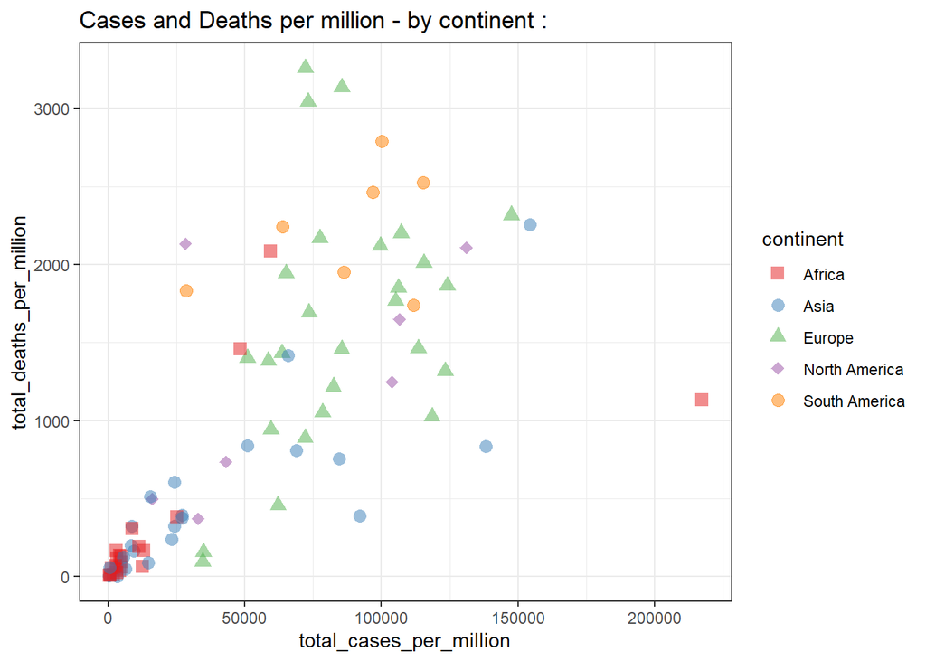

```r
normalversion <- ggplot(subOpenCovid,
       aes(x=total_cases_per_million,
           y=total_deaths_per_million,
           colour = continent,
           shape = continent)) +
  geom_point(size = 3, alpha = 0.5) +
  scale_shape_manual(values=c(15:19)) +
  scale_colour_brewer(palette = "Set1") +
  ggtitle("Cases and Deaths per million - by continent :") +
  theme_bw()

loglogversion <- ggplot(subOpenCovid,
       aes(x=total_cases_per_million,
           y=total_deaths_per_million,
           colour = continent,
           shape = continent)) +
  geom_point(size = 3, alpha = 0.5) +
  scale_shape_manual(values=c(15:19)) +
  scale_colour_brewer(palette = "Set1") +
  ggtitle("Cases and Deaths per million - by continent :") +
  theme_bw() +
  scale_x_continuous(trans = 'log10') +
  scale_y_continuous(trans = 'log10')

normalversion
```

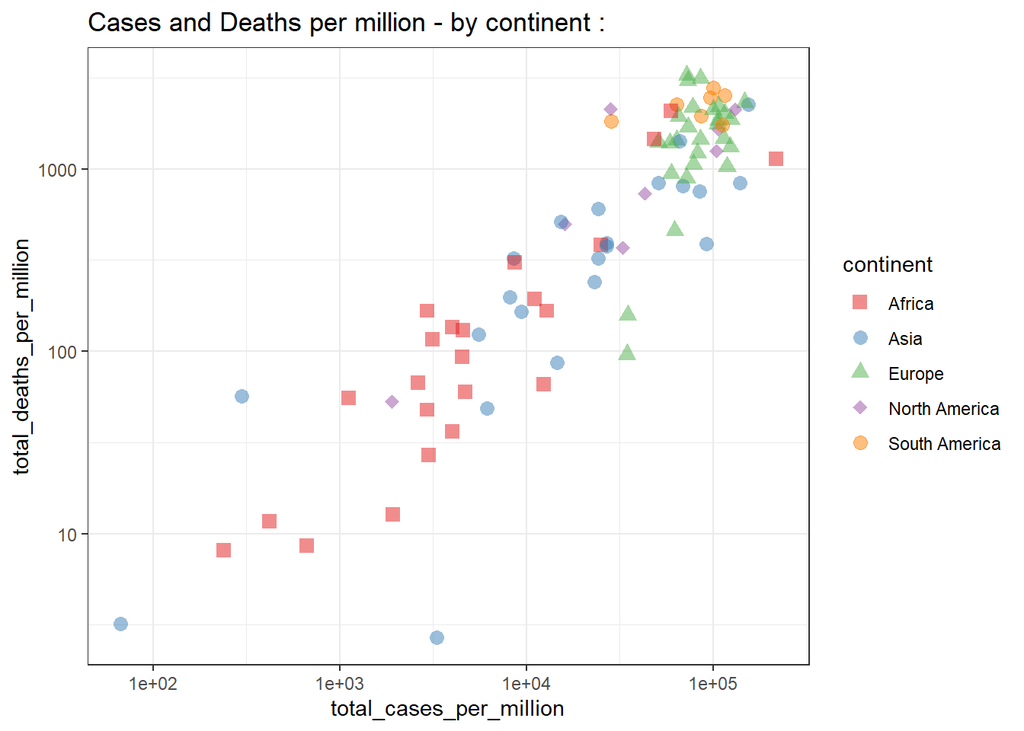

```r
loglogversion
```

And again the “pairs” graphics from last time as a big overview :

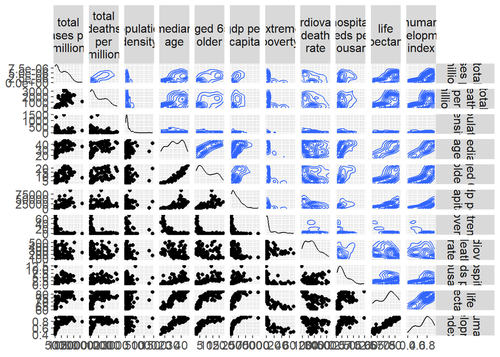

```r
subOpenCovid <- dplyr::mutate(subOpenCovid,
                              #
                              death_per_case = total_deaths_per_million / total_cases_per_million
                              ) #normalize deaths to number of cases
pair_plot <- ggpairs(
  subOpenCovid[,c(3:13)],
  upper = list(continuous = "density", combo = "box_no_facet"),
  lower = list(continuous = "points", combo = "dot_no_facet"),
  columnLabels = gsub('_', ' ', colnames(subOpenCovid[,c(3:13)]), fixed = T),
  labeller = label_wrap_gen(10),
  progress = FALSE
  )


pair_plot +
  theme(text = element_text(size=15))
```

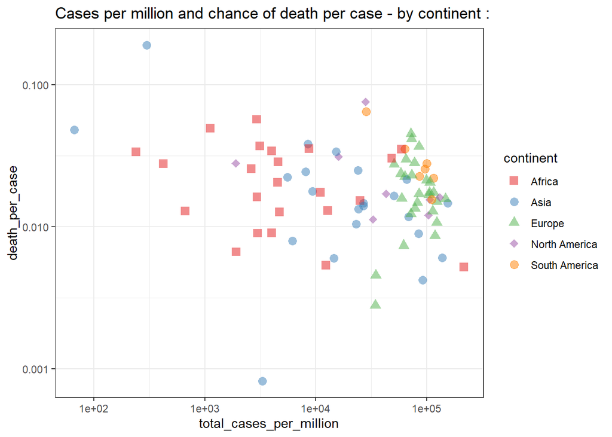

```r
ggplot(subOpenCovid,
       aes(x=total_cases_per_million,
           y=death_per_case,
           colour = continent,
           shape = continent)) +
  geom_point(size = 3, alpha = 0.5) +
  scale_shape_manual(values=c(15:19)) +
  scale_colour_brewer(palette = "Set1") +
  ggtitle("Cases per million and chance of death per case - by continent :") +
  theme_bw() +
  scale_x_continuous(trans = 'log10') +
  scale_y_continuous(trans = 'log10')
```

## Getting ready for the cluster analyses and dimensionality reduction

### Preparation steps

Remove the obvious deterministic dependency :

```r
subOpenCovid %<>% dplyr::select(., -total_deaths_per_million)
```

Take out the categorical variables for the time being :

```r
clusterDF <- dplyr::select(subOpenCovid, -continent, -location)
```

Express as standardized scores (scaling), assuming everything should be converted to standardized z-statistic. This assumption may not be true for highly skewed distributions! But for now we ignore this obvious danger. In practice, we would alreayd have done quite a lot of data exploration and looked at the variance within each variable, so we should be able to make an informed choice about this.

```r
clusterDF_scaled <- scale(clusterDF) #assuming everything should be converted to standardized z-statistic
#this assumption may not be true for highly skewed distributions! But for now we ignore this obvious danger.
```

The needed libraries for clustering analysis :

```r
installRequiredPackages(
  c("cluster","factoextra")
)
```

```
## [1] "cluster"    "factoextra"
```

## Re-visiting principal components

[A video explaining Principal Component Analysis](https://www.youtube.com/watch?v=FgakZw6K1QQ)

[An intuitive visual explanation of principal components analysis as a dimensionality REDUCTION tool](https://setosa.io/ev/principal-component-analysis/)

```r
pca_DF <- prcomp(clusterDF_scaled) # Perform Principal Component Analysis
```

Let’s create a PCA score plot to inspect the principal components

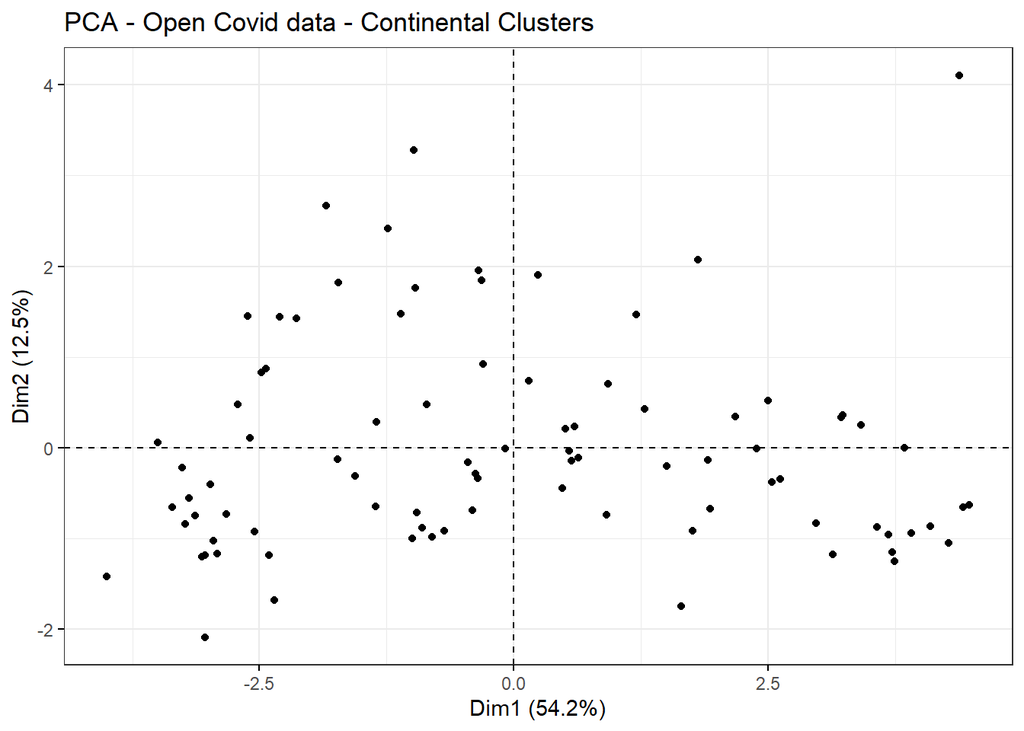

```r
fviz_pca_ind(pca_DF, title = "PCA - Open Covid data - Continental Clusters",
             geom = "point",
             ggtheme = theme_bw())
```

A biplot can also show us what the principcal components mean.

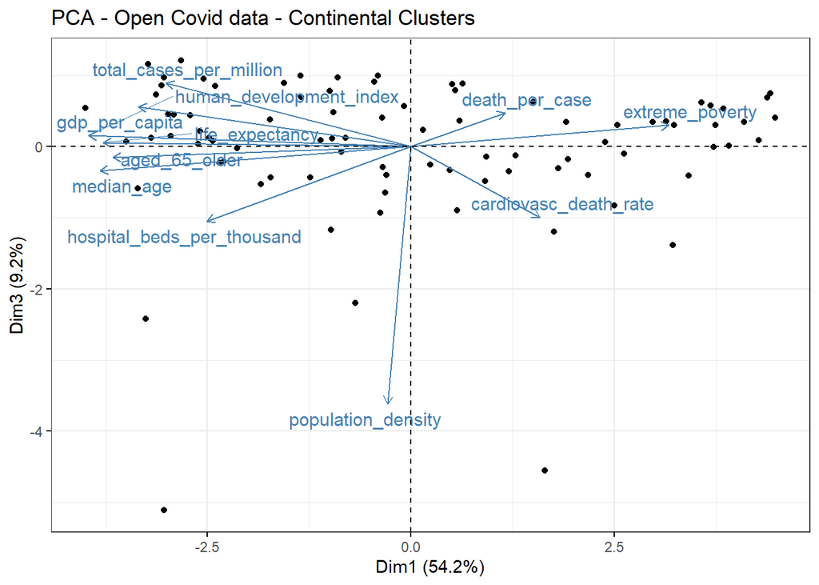

```r
fviz_pca_biplot(pca_DF, title = "PCA - Open Covid data - Continental Clusters",
             axes = c(1,3)
,                geom = "point",
             ggtheme = theme_bw(),
             repel = T)
```

Can we already see some seperation between known groups? Between continents for example?

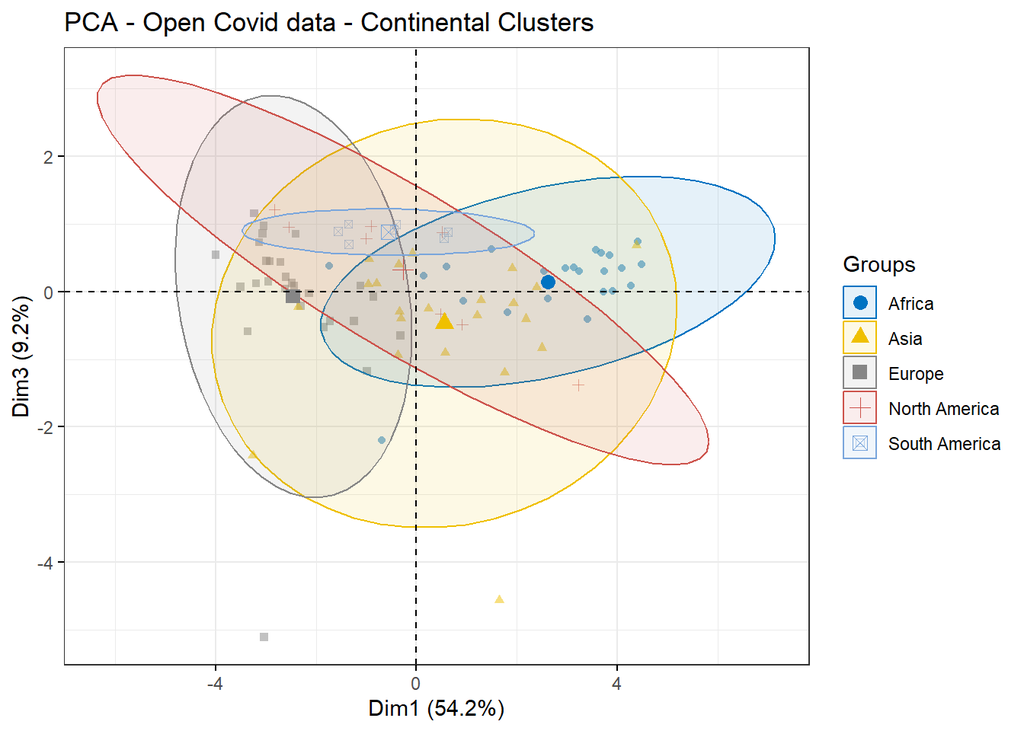

```r
fviz_pca_ind(pca_DF, title = "PCA - Open Covid data - Continental Clusters",
             axes = c(1,3),
             habillage = subOpenCovid$continent,
             palette = "jco",
             geom = "point",
             ggtheme = theme_bw(),
             alpha.ind = 0.5,
             addEllipses = TRUE,
             legend = "right")
```

What about the other PCs? Aren’t they important as well?

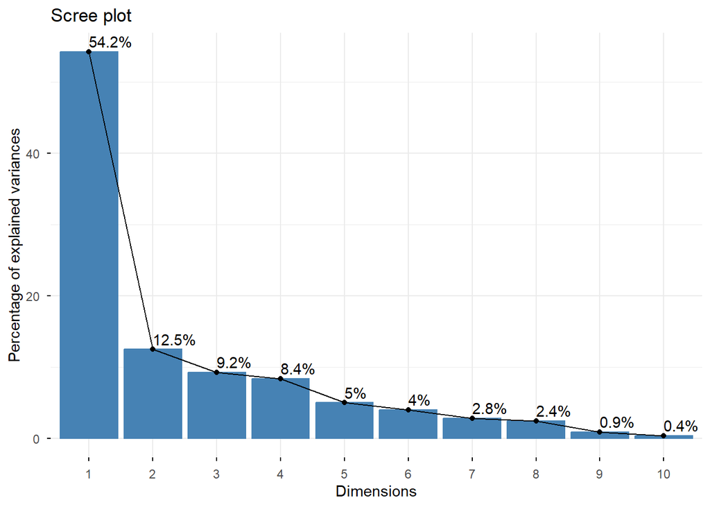

```r
fviz_eig(pca_DF, addlabels = TRUE)
```

## Experimentations with clustering tendency and “similarity”

### Visual estimation using a clustering (Hopkins’) statistic

```r
gradient.color <- list(low = "red",  high = "white")

hopkinsClustering <- get_clust_tendency(clusterDF_scaled,
                                        n = nrow(clusterDF_scaled)-1,
                                        gradient = gradient.color)
hopkinsClustering$hopkins_stat # if H < 0.5, it is unlikely that there are statistically significant clusters.
```

```
## [1] 0.7998663
```

Let’s look at the ordered dissimilarity matrix, which can also give insights into potential clusters

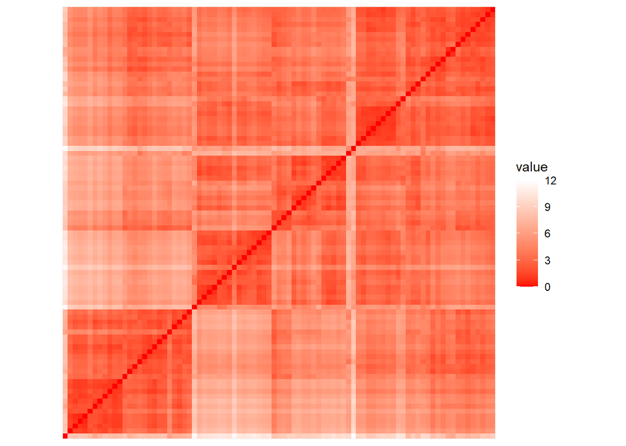

```r
hopkinsClustering$plot + coord_fixed()
```

### Distance (or similarity) metric

In order to define clusters, we need a measurement of similarity. Mathematically, similarity is calculated as a type of “distance”. We are used to think of distance in kilometers or miles, but it is also possible to propose it is the *sum of squares of the difference between any two subjects’ values*. In this case it is the classical Euclidean (flat space) distance but you could imagine an infinite variety of ways to define the similarity between two subjects etc.

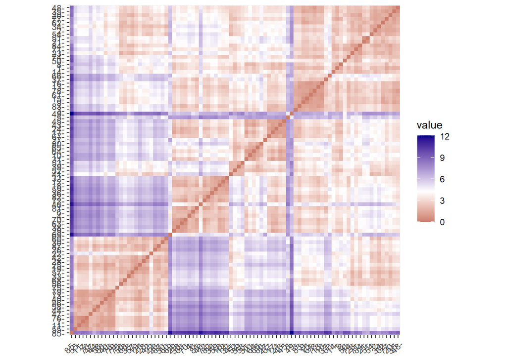

```r
euclid.dist <- get_dist(clusterDF_scaled, method = "euclidean")

fviz_dist(euclid.dist,
   gradient = list(low = "darkred", mid = "white", high = "darkblue")) +
  coord_fixed()
```

### Experimenting with different “distance” metrics

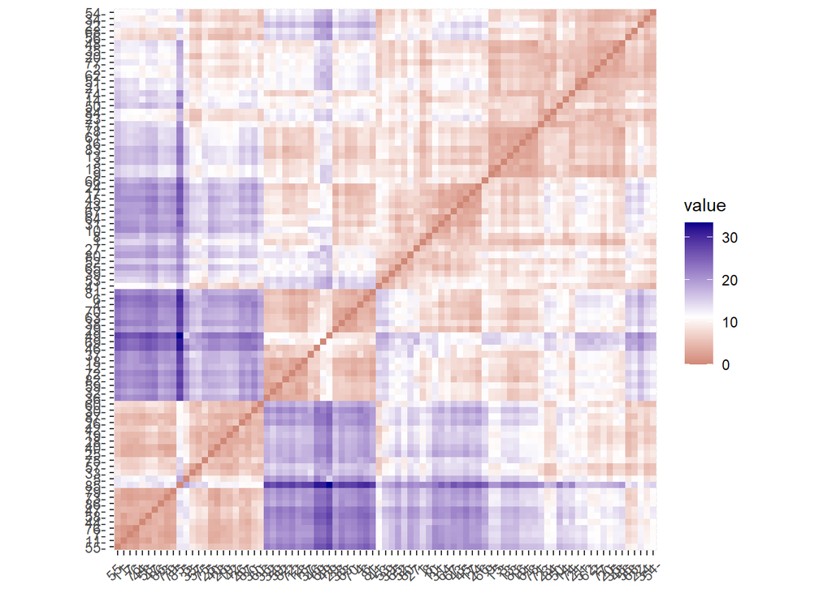

```r
manhattan.dist <- get_dist(clusterDF_scaled, method = "manhattan")

fviz_dist(manhattan.dist,
   gradient = list(low = "darkred", mid = "white", high = "darkblue")) +
  coord_fixed()
```

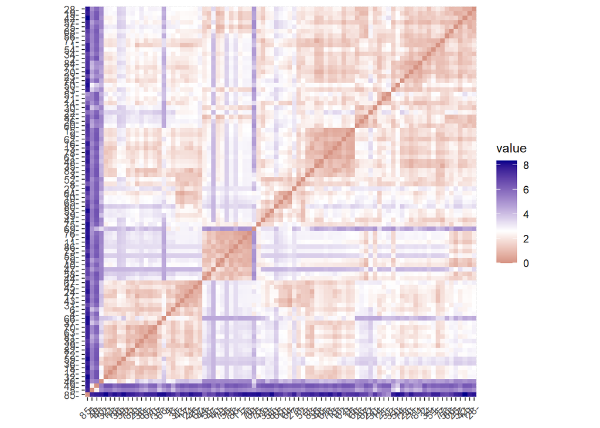

```r
maximum.dist <- get_dist(clusterDF_scaled, method = "maximum")

fviz_dist(maximum.dist,
   gradient = list(low = "darkred", mid = "white", high = "darkblue")) +
  coord_fixed()
```

### Correlation-based distances

Correlation says that two subjects similar if their value over all variables are highly correlated, even if the actual values of one specific variable might be far apart in terms of Euclidean distance. A correlation distance of exactly zero happens when two subjects are perfectly correlated even if their values are widely different.

Example, patient Y has every single measurement that is perfectly triple the measurement of patient X. Then the correlation distance between X and Y is zero even though the absolute values of the measurements are widely different.

**Please note this difference for interpretation, because normally think that zero implies NO correlation**.

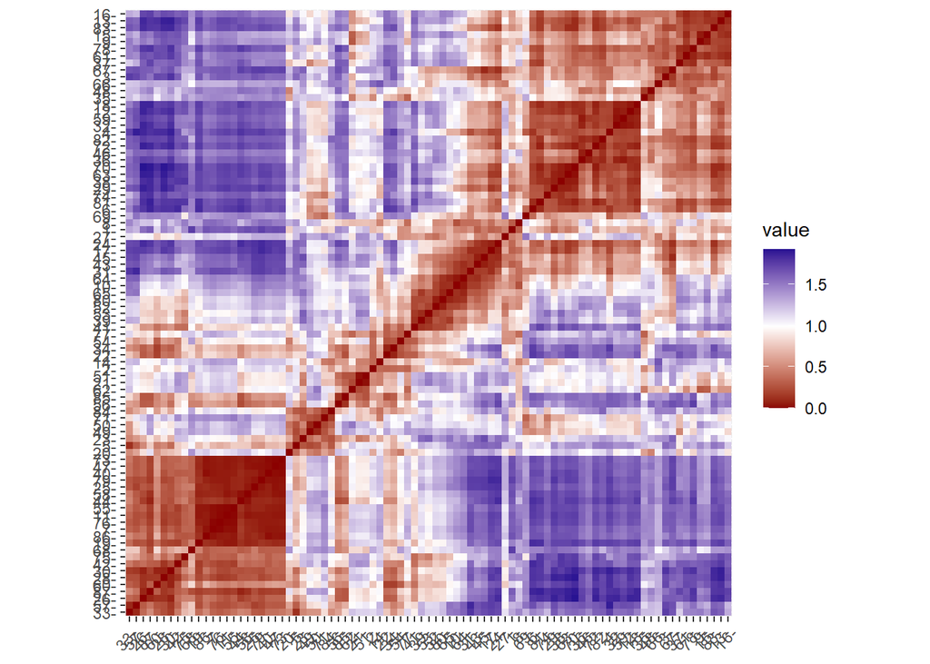

```r
pearson.dist <- get_dist(clusterDF_scaled, method = "pearson")

fviz_dist(pearson.dist,
   gradient = list(low = "darkred", mid = "white", high = "darkblue")) +
  coord_fixed()
```

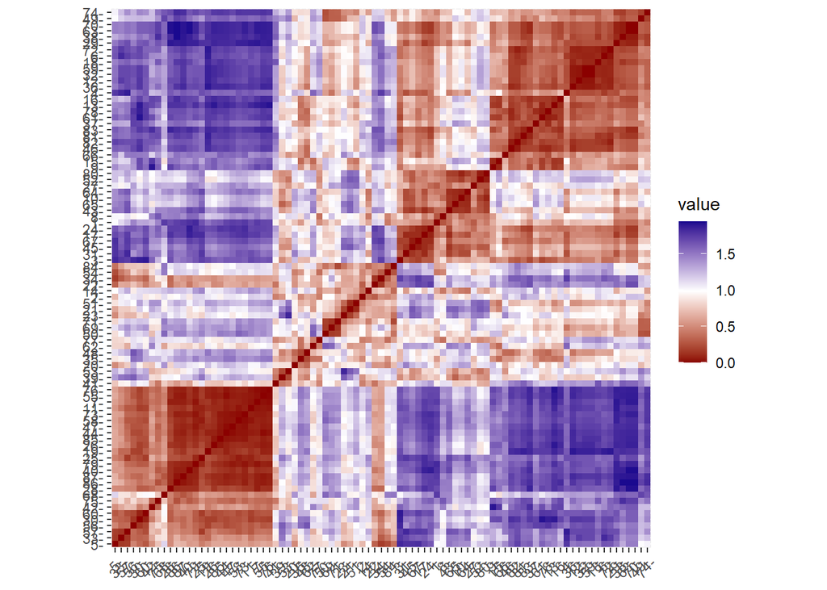

```r
spearman.dist <- get_dist(clusterDF_scaled, method = "spearman")

fviz_dist(spearman.dist,
   gradient = list(low = "darkred", mid = "white", high = "darkblue")) +
  coord_fixed()
```

The balance of visual analysis suggests to us that, one way or another, there is quite a high clustering tendency in this dataset, so we might be able to find the clusters and try to interpret them.

## K-means clustering

I am going to start with just a bit of a guess.

```r
set.seed(1299) # Setting random number generator seed - could be useful if you want the same result each time
kmeans.re <- kmeans(clusterDF_scaled, centers = 4, nstart = 25)
kmeans.re
```

```
## K-means clustering with 4 clusters of sizes 18, 26, 17, 26
##
## Cluster means:
##   total_cases_per_million population_density median_age aged_65_older
## 1               0.6204834         0.36466073  1.0235415     1.2037765
## 2              -0.9475288         0.08899773 -1.2060239    -1.0375121
## 3               0.9551128        -0.37061455  0.8194308     0.7733358
## 4              -0.1065335        -0.09913026 -0.0383634    -0.3015142
##   gdp_per_capita extreme_poverty cardiovasc_death_rate
## 1     1.53023926      -0.5634243            -1.1123092
## 2    -0.88182381       1.2413385             0.2870546
## 3     0.09430736      -0.5341558             0.9454448
## 4    -0.23923510      -0.5020198            -0.1351698
##   hospital_beds_per_thousand life_expectancy human_development_index
## 1                  0.4583062       1.2362367               1.1915062
## 2                 -0.7975668      -1.2973587              -1.3151830
## 3                  1.2524844       0.1648993               0.5381678
## 4                 -0.3386542       0.3336838               0.1384151
##   death_per_case
## 1    -0.41979394
## 2     0.19368317
## 3    -0.07484287
## 4     0.14587913
##
## Clustering vector:
##  [1] 4 4 3 1 2 1 2 3 4 3 2 1 4 4 4 4 3 1 2 4 4 4 4 3 2 2 3 2 1 2 3 1 2 4 4 1 1 1
## [39] 3 2 4 2 3 2 3 1 2 4 1 4 4 3 3 4 2 2 2 2 1 2 4 4 1 3 3 3 3 2 1 1 4 1 2 4 2 2
## [77] 4 4 2 3 1 1 4 4 2 2 2
##
## Within cluster sum of squares by cluster:
## [1]  93.62559 155.77120  61.27186  82.72324
##  (between_SS / total_SS =  58.4 %)
##
## Available components:
##
## [1] "cluster"      "centers"      "totss"        "withinss"     "tot.withinss"
## [6] "betweenss"    "size"         "iter"         "ifault"
```

But there is a much more systematic way to search for the clusters, which you have seen previously. The slightly more subjective decision is where on the “elbow” to choose.

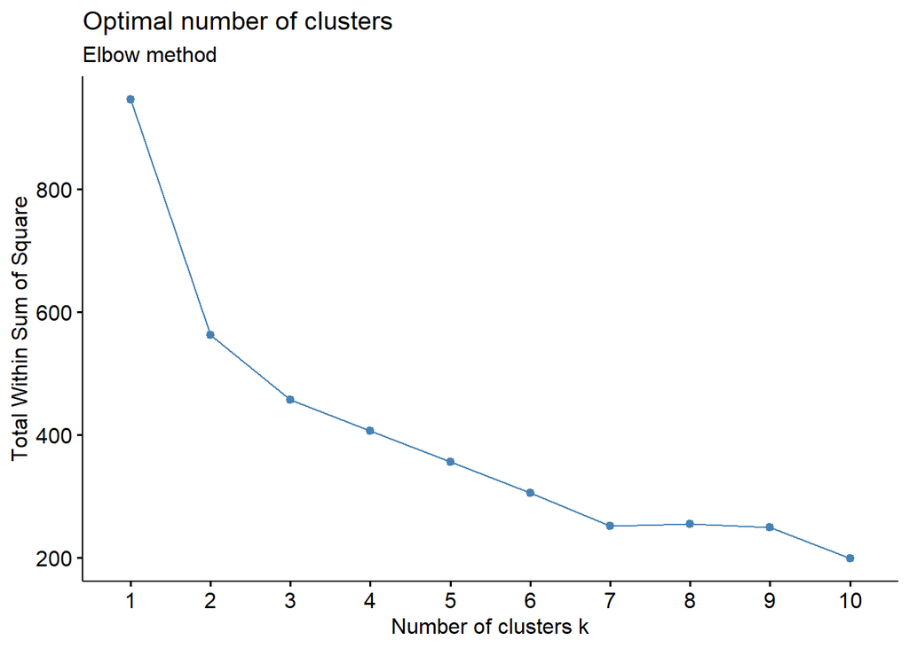

```r
fviz_nbclust(clusterDF_scaled, kmeans, method = "wss") +
    #geom_vline(xintercept = 4, linetype = 2)+
  labs(subtitle = "Elbow method")
```

We can alos use the silhouette score, which is less subjective

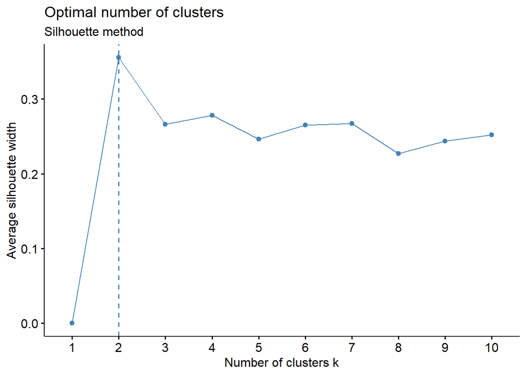

```r
fviz_nbclust(clusterDF_scaled, kmeans, method = "silhouette") +
  labs(subtitle = "Silhouette method")
```

The elbow point seems to be at two, and the silhouette score is also highest for two clusters, so let’s give that a try.

```r
kmeans.re <- kmeans(clusterDF_scaled, centers = 2, nstart = 25) # Here we set the number of centers/clusters to 2
membership <- kmeans.re$cluster # Extract for each patient to which cluster they were assigned

subOpenCovid$membership <- as.factor(membership)
```

Now re-doing the earlier plot, but instead of using the predefined continents, I’ll use the cluster memberships assigned by K-Means:

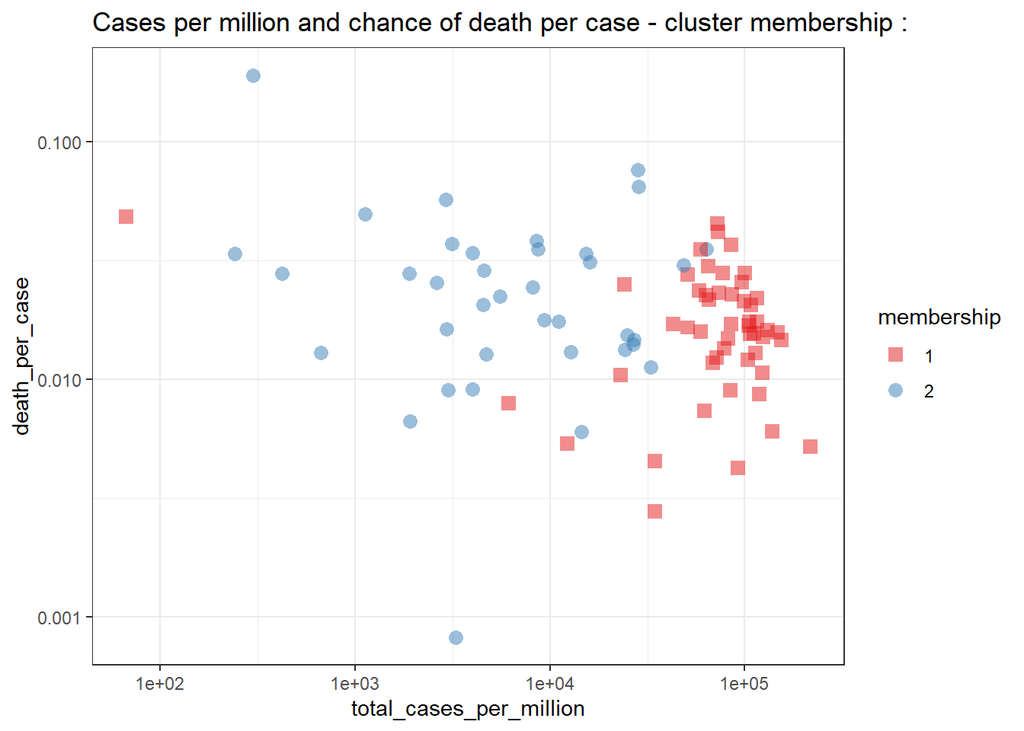

```r
ggplot(subOpenCovid,
       aes(x=total_cases_per_million,
           y=death_per_case,
           colour = membership,
           shape = membership)) +
  geom_point(size = 3, alpha = 0.5) +
  scale_shape_manual(values=c(15:17)) +
  scale_colour_brewer(palette = "Set1") +
  ggtitle("Cases per million and chance of death per case - cluster membership :") +
  theme_bw() +
  scale_x_continuous(trans = 'log10') +
  scale_y_continuous(trans = 'log10')
```

### Heirarchical clustering (compare with K-means clustering)

One of the potential criticisms about K-means clustering if the reduced transparency or subjectivity when choosing how many clusters. It is harder to visualize what would happen if we defined more or fewer clusters other than to do it and try it.

In contrast hierarchical clustering is a **tree-based** representation of the data, which is also known as a “dendrogram”. We will be able to see all the possible clusters at once, without having to define the number of clusters up front. However we need to decide which level to “cut” the tree, which then gives us the cluster memberships.

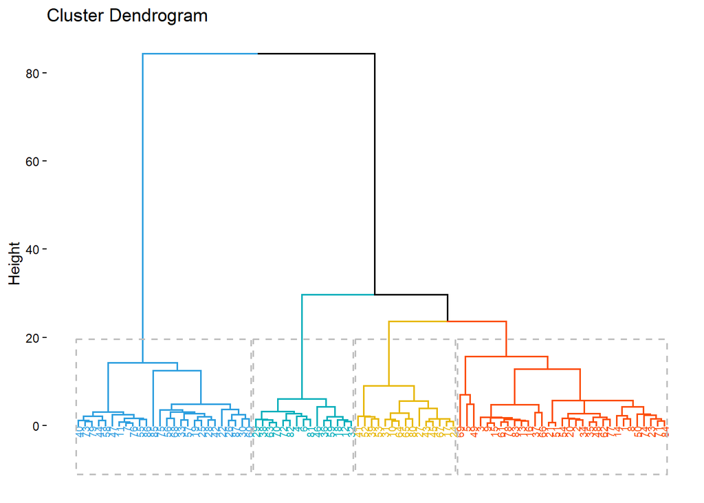

```r
dis <- dist(clusterDF_scaled, method = "euclidean") # let's try it with euclidean distance
res.hc.euclid <- hclust(dis,  method = "ward.D")

fviz_dend(res.hc.euclid, k = 4, # Cut in four groups
          cex = 0.5, # label size
          k_colors = c("#2E9FDF", "#00AFBB", "#E7B800", "#FC4E07"),
          color_labels_by_k = TRUE, # color labels by groups
          rect = TRUE # Add rectangle around groups
          )
```

No we re-do the earlier plot with these four hierarchical clusters

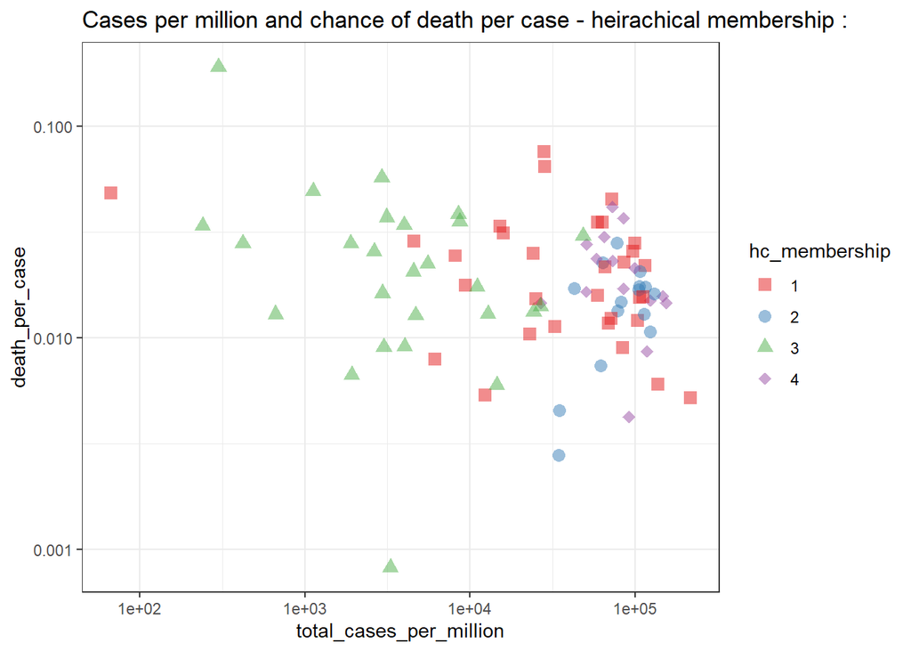

```r
hc_membership <- cutree(res.hc.euclid, k = 4)

subOpenCovid$hc_membership <- as.factor(hc_membership)

ggplot(subOpenCovid,
       aes(x=total_cases_per_million,
           y=death_per_case,
           colour = hc_membership,
           shape = hc_membership)) +
  geom_point(size = 3, alpha = 0.5) +
  scale_shape_manual(values=c(15:18)) +
  scale_colour_brewer(palette = "Set1") +
  ggtitle("Cases per million and chance of death per case - heirachical membership :") +
  theme_bw() +
  scale_x_continuous(trans = 'log10') +
  scale_y_continuous(trans = 'log10')
```

The separation between the clusters is not so obvious in this projected view of deaths per case versus total cases per million population. It is left as a bit of a data exploration experiment if you can find **other data visualization views** that might be able to help interpret the underlying signal of the clusters.

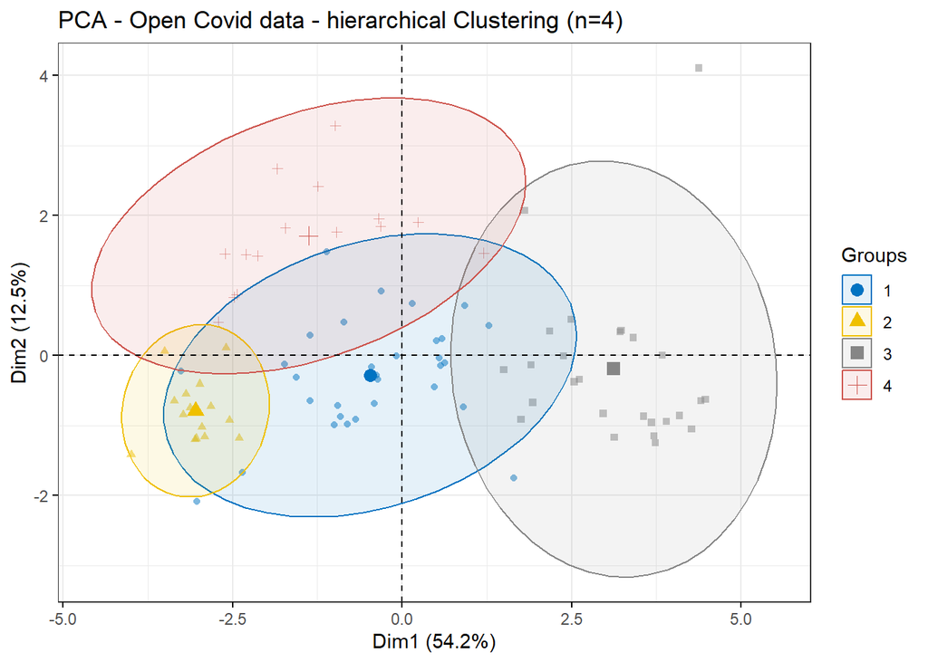

```r
fviz_pca_ind(pca_DF, title = "PCA - Open Covid data - hierarchical Clustering (n=4)",
             habillage = subOpenCovid$hc_membership,
             palette = "jco",
             geom = "point",
             ggtheme = theme_bw(),
             alpha.ind = 0.5,
             addEllipses = TRUE,
             legend = "right")
```

Create a biplot to get an idea of which variables seperate the clusters.

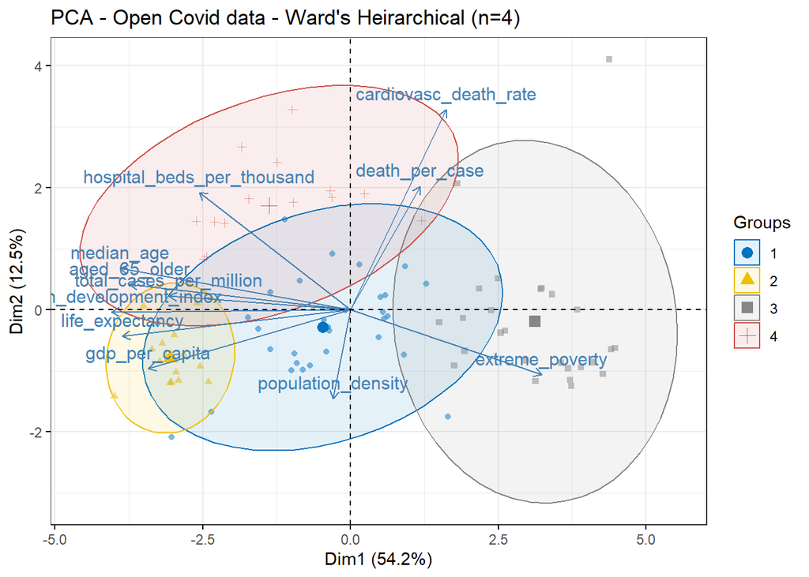

```r
fviz_pca_biplot(pca_DF, title = "PCA - Open Covid data - Ward's Heirarchical (n=4)",
             habillage = subOpenCovid$hc_membership,
             palette = "jco",
             geom = "point",
             ggtheme = theme_bw(),
             alpha.ind = 0.5,
             addEllipses = TRUE,
             legend = "right")
```

To characterise the clusters it is always a good idea to generate some descriptive statistics, describing and comparing the individual clusters